# 1. Introduction to Data Exploration

# 4. Investigating the target `SalePrice`

## 4.5.1 `GrLivArea`

```python
feature_description('GrLivArea')
```

```
GrLivArea: Above grade (ground) living area square feet
```

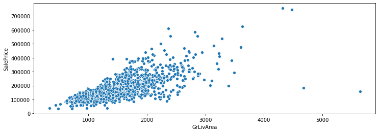

```python
plt.subplots(figsize=(12, 4))
scatter(df, 'GrLivArea')
```

Taking notes:

- **Name**: `GrLivArea`
- **Type**: `Numeric`
- **Segment**: `Space`
- **Expectation**: `High`
- **Conclusions**:
- **Comments**:
  - `SalePrice` has a **linear relationship** with `GrLivArea`
  - Both seem **positively correlated**
  - Some weird points (outliers), out of the cloud
  - Spreads as both values increase

# 4. Investigating the target `SalePrice`

## 4.5.2 `TotalBsmtSF`

```python
feature_description('TotalBsmtSF')
```

```
TotalBsmtSF: Total square feet of basement area
```

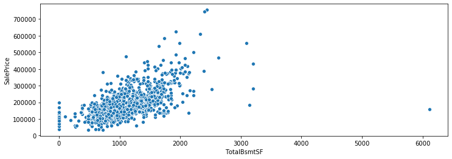

```python
plt.subplots(figsize=(12, 4))
scatter(df, 'TotalBsmtSF')
```

Taking notes:

- **Name**: `TotalBsmtSF`
- **Type**: `Numeric`
- **Segment**: `Space`
- **Expectation**: `High`
- **Conclusions**:
- **Comments**:
  - `SalePrice` has a **linear relationship** with `TotalBsmtSF`, but more suave
  - Sometimes, the linear relation shoots up (exponentially?)
  - Both seem **positively correlated**, although less than `GrLivArea`
  - Some weird points (outliers), out of the cloud
  - Spreads as both values increase
  - More *noisy* than `GrLivArea`

# 4. Investigating the target `SalePrice`

## 4.5.3. `OverallQual`

```python
feature_description('OverallQual')
```

```
OverallQual: Rates the overall material and finish of the house
       10	Very Excellent
       9	Excellent
       8	Very Good
       7	Good
       6	Above Average
       5	Average
       4	Below Average
       3	Fair
       2	Poor
       1	Very Poor
```

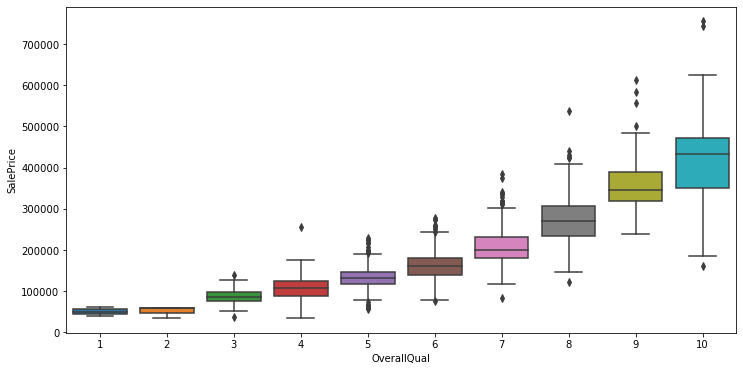

```python
plt.subplots(figsize=(12, 6))
boxplot(df, 'OverallQual')
```

Taking notes:

- **Name**: `OverallQual`
- **Type**: `Numeric`
- **Segment**: `Building`
- **Expectation**: `High`
- **Conclusions**:
- **Comments**:
  - `SalePrice` seems to enjoy `OverallQual`
  - Makes sense, more quality means higher price
  - **`[NOTE]`**: As quality gets higher, it is also shows more **variability**

# 4. Investigating the target `SalePrice`

## 4.5.4. `YearBuilt`

```python
feature_description('YearBuilt')
```

```
YearBuilt: Original construction date
```

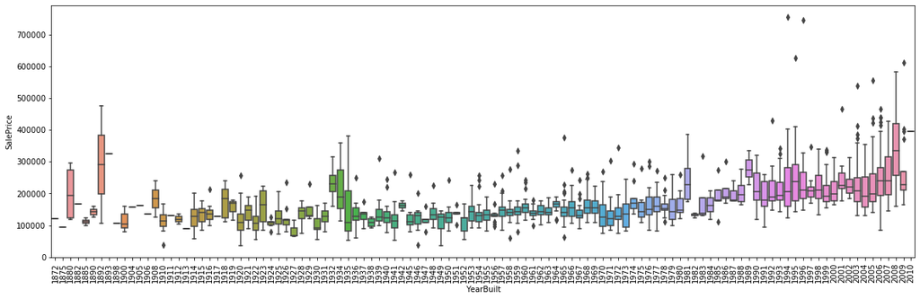

```python
plt.subplots(figsize=(20, 6))
plt.xticks(rotation=90)
boxplot(df, 'YearBuilt', x_size=20)
```

Taking notes:

- **Name**: `YearBuilt`
- **Type**: `Numeric`
- **Segment**: `Building`
- **Expectation**: `High`
- **Conclusions**:
- **Comments**:
  - We don't see a clear tendency
  - I'd say that you'd rather spend more money in a new house rather than an old one
  - **`[NOTE]`**: We don't know if `SalePrice` takes inflation into account (if it is not it's hard to compare over the years)

# 4. Investigating the target `SalePrice`

## 4.5.5. `1stFlrSF`

```python
feature_description('1stFlrSF')
```

```
1stFlrSF: First Floor square feet
```

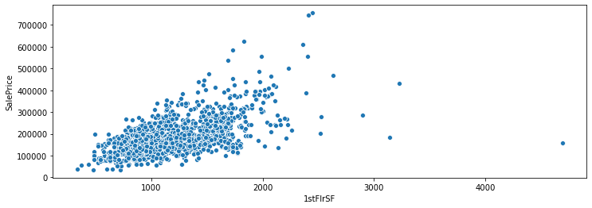

```python
plt.subplots(figsize=(12, 4))
scatter(df, '1stFlrSF')
```

# 4. Investigating the target `SalePrice`

## 4.6. Summary

# 5. Further analysis - Working Smart

[figure not shown]

# 5. Further analysis - Working Smart

## 5.1. Introduction

- We looked at variables we **thought** were relevant
  - They had a linear relationship with `SalePrice`
  - **But**, can be **subjective** and has no numerical basis!
- We can look for linear relations **objectively** - with **correlations**!

Plan:

1. Investigate **correlation matrix** (every feature vs every feature)
2. `SalePrice` **correlation matrix**
3. **Scatter plots** between correlated variables

# 5. Further analysis - working smart

## 5.2. Correlation

- **`[CORRELATION]`**: a mutual relationship or connection between two random variables
  - Commonly refers to the degree to which a pair of variables are **linearly related**
  - Indicate a **predictive relationship** that can be exploited in practice
  - Normally come between **[-1, 1]**

[figure not shown]

- One of the most used correlations is the **Pearson** correlation index
  - Sensitive only to a **linear relationship** between two variables

$$ r_{x,y}=\frac{\sum (x_i - \bar{x})(y_i - \bar{y})}{\sqrt{\sum (x_i - \bar{x})^2\sum(y_i - \bar{y})^2}} $$

- **Pandas** allows calculating correlations by using `pd.DataFrame.corr()`

```python
corrmat = df.corr(method='pearson')
corrmat.head()
```

|  | Id | MSSubClass | LotFrontage | LotArea | OverallQual | OverallCond | YearBuilt | YearRemodAdd | MasVnrArea | BsmtFinSF1 | ... | WoodDeckSF | OpenPorchSF | EnclosedPorch | 3SsnPorch | ScreenPorch | PoolArea | MiscVal | MoSold | YrSold | SalePrice |
| --- | --- | --- | --- | --- | --- | --- | --- | --- | --- | --- | --- | --- | --- | --- | --- | --- | --- | --- | --- | --- | --- |
| Id | 1.000000 | 0.011156 | -0.010601 | -0.033226 | -0.028365 | 0.012609 | -0.012713 | -0.021998 | -0.050298 | -0.005024 | ... | -0.029643 | -0.000477 | 0.002889 | -0.046635 | 0.001330 | 0.057044 | -0.006242 | 0.021172 | 0.000712 | -0.021917 |
| MSSubClass | 0.011156 | 1.000000 | -0.386347 | -0.139781 | 0.032628 | -0.059316 | 0.027850 | 0.040581 | 0.022936 | -0.069836 | ... | -0.012579 | -0.006100 | -0.012037 | -0.043825 | -0.026030 | 0.008283 | -0.007683 | -0.013585 | -0.021407 | -0.084284 |
| LotFrontage | -0.010601 | -0.386347 | 1.000000 | 0.426095 | 0.251646 | -0.059213 | 0.123349 | 0.088866 | 0.193458 | 0.233633 | ... | 0.088521 | 0.151972 | 0.010700 | 0.070029 | 0.041383 | 0.206167 | 0.003368 | 0.011200 | 0.007450 | 0.351799 |
| LotArea | -0.033226 | -0.139781 | 0.426095 | 1.000000 | 0.105806 | -0.005636 | 0.014228 | 0.013788 | 0.104160 | 0.214103 | ... | 0.171698 | 0.084774 | -0.018340 | 0.020423 | 0.043160 | 0.077672 | 0.038068 | 0.001205 | -0.014261 | 0.263843 |
| OverallQual | -0.028365 | 0.032628 | 0.251646 | 0.105806 | 1.000000 | -0.091932 | 0.572323 | 0.550684 | 0.411876 | 0.239666 | ... | 0.238923 | 0.308819 | -0.113937 | 0.030371 | 0.064886 | 0.065166 | -0.031406 | 0.070815 | -0.027347 | 0.790982 |

5 rows × 38 columns

- **`[NOTE]`**: `Categorical` features were automatically dropped from calculations
  - One cannot calculate correlations between `Categorical` variables (at least, directly)
- Viewing a `pd.DataFrame` with numbers doesn't help us a lot
- We will need an `Heatmap` to help us visualize this

# 5. Further analysis - working smart

## 5.3. New plot - `Heatmap`

- `Heatmaps` visualise data through **variations in colouring**
- Useful for cross-examining **multivariate data**
  - By placing variables in rows and columns
  - Colouring the cells within the table

### Looks

[figure not shown]

### How to interpret

- Legend is required
- Numerical data is **color coded** - we need to know the **ranges**
- The palette of colors is called - **colormap**
- Can be **continuous** or **discrete**

[figure not shown]

### When to use

- Good for showing **variance** across multiple variables, revealing any **patterns**
  - Any variables are **similar** to each other?
  - **Correlated** variables?

# 5. Further analysis - working smart

## 5.4. Example - Correlation `Heatmap`

- We already have a (square) **table** of **correlated** variables
- We can make use of `sns.heatmap` to produce an `Heatmap`

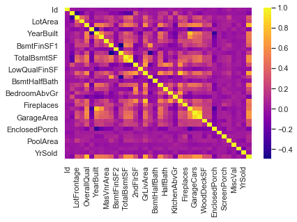

```python
corrmat = df.corr()
sns.heatmap(corrmat, cmap='plasma')
```

- Put it in a function and making the size bigger
- Let's investigate variables of **interest** - **high** or **low** correlations

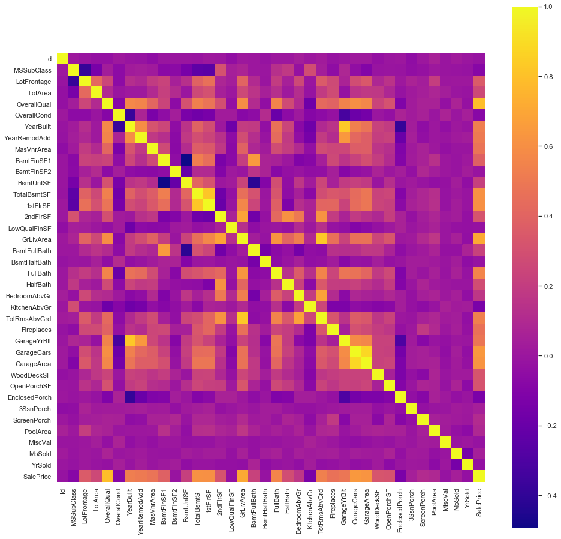

```python
def corr_heatmap(df):
    corrmat = df.corr()
    fig = sns.heatmap(corrmat, square=True, cmap='plasma')
    return fig
plt.subplots(figsize=(16,16))
corr_heatmap(df)
```

- Pay attention to:
  - `TotalBsmtSF` and `1stFlrSF` - positive **correlation**
  - Garage related variables - more `GarageArea` more `GarageCars` - they give almost the same information
- Detecting redundant variables is great in our case
  - So we don't need to look at 80 variables
- `SalePrice` correlations - old friends:
  - `GrLivArea`, `ToalBsmtSF` and `OverallQual`
  - `YearBuilt`
  - A couple others - let's look at them with a more **focused** eye

# 5. Further analysis - working smart

## 5.5. Focused Correlation Heatmap

- Let's select the 10 **most correlated** variables to `SalePrice`

```python
saleprice_corr = corrmat[['SalePrice']].abs()
saleprice_corr.head()
```

|  | SalePrice |
| --- | --- |
| Id | 0.021917 |
| MSSubClass | 0.084284 |
| LotFrontage | 0.351799 |
| LotArea | 0.263843 |
| OverallQual | 0.790982 |

```python
sorted_saleprice_corr = saleprice_corr.sort_values(by='SalePrice', ascending=False)
sorted_saleprice_corr.head()
```

|  | SalePrice |
| --- | --- |
| SalePrice | 1.000000 |
| OverallQual | 0.790982 |
| GrLivArea | 0.708624 |
| GarageCars | 0.640409 |
| GarageArea | 0.623431 |

```python
k = 10 # number of highest correlations to SalePrice
top_saleprice_corr = sorted_saleprice_corr[:k]
top_saleprice_corr
```

|  | SalePrice |
| --- | --- |
| SalePrice | 1.000000 |
| OverallQual | 0.790982 |
| GrLivArea | 0.708624 |
| GarageCars | 0.640409 |
| GarageArea | 0.623431 |
| TotalBsmtSF | 0.613581 |
| 1stFlrSF | 0.605852 |
| FullBath | 0.560664 |
| TotRmsAbvGrd | 0.533723 |
| YearBuilt | 0.522897 |

```python
cols = list(top_saleprice_corr.index)
cols
```

[output not shown]

[figure not shown]

```python
cm = df[cols].corr(method='pearson')
plt.subplots(figsize=(16, 16))
hm = sns.heatmap(cm, annot=True, square=True, yticklabels=cols, xticklabels=cols, cmap='plasma')
plt.show()
```

- Put it in a function for later use

```python
def corr_heatmap(df, k=None):
    cm = df.corr()
    if k is not None:
        saleprice_corr = corrmat[['SalePrice']].abs()
        sorted_saleprice_corr = saleprice_corr.sort_values(by='SalePrice', ascending=False)
        top_saleprice_corr = sorted_saleprice_corr[:k]
        cols = list(top_saleprice_corr.index)
        cm = df[cols].corr(method='pearson')
    fig = sns.heatmap(cm, annot=True, square=True, yticklabels=cols, xticklabels=cols, cmap='plasma')
    return fig
```

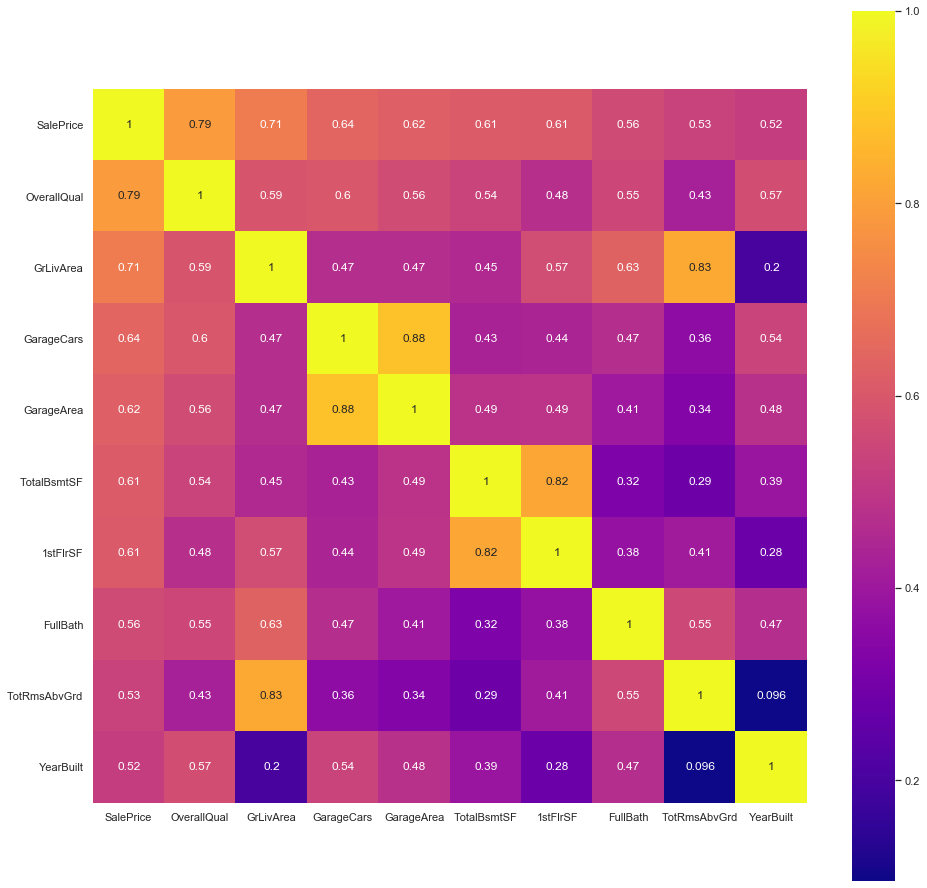

```python
plt.subplots(figsize=(16,16))
corr_heatmap(df, k=10)
```

- Most **correlated** with `SalePrice`
  - `OverallQual`, `GrLivArea` and `TotalBsmtSF` - check!
  - `Garage` variables - redundant! We can keep just `GarageCars` (more correlated with `SalePrice`)
  - `TotalBsmtSF` and `1stFloor` - we'll keep both
  - `FullBath` - people like to take good showers, I guess.
  - `GrLivArea` and `TotRmsAbvGrd` - very **correlated**. We can just keep `GrLivArea`
  - `YearBuilt` - an overall good indicator
- We get to keep these variables:
  - `OverallQual`, `GrLivArea`, `TotalBsmtSF` and `YearBuilt` - our expectations were right!
  - `GarageCars` - seems to be a good indicator as well
  - `1stFlrSF` - some houses might not have a basement.
  - `FullBath` - unrelated to our other variables

# 5. Further analysis - working smart

## 5.6. Investigating Correlated Variables - `PairPlot`

- We can visualize `Histograms` and `Scatter Plots` of all variables in just one plot - the `PairPlot`
- We can make use of `sns.pairplot`

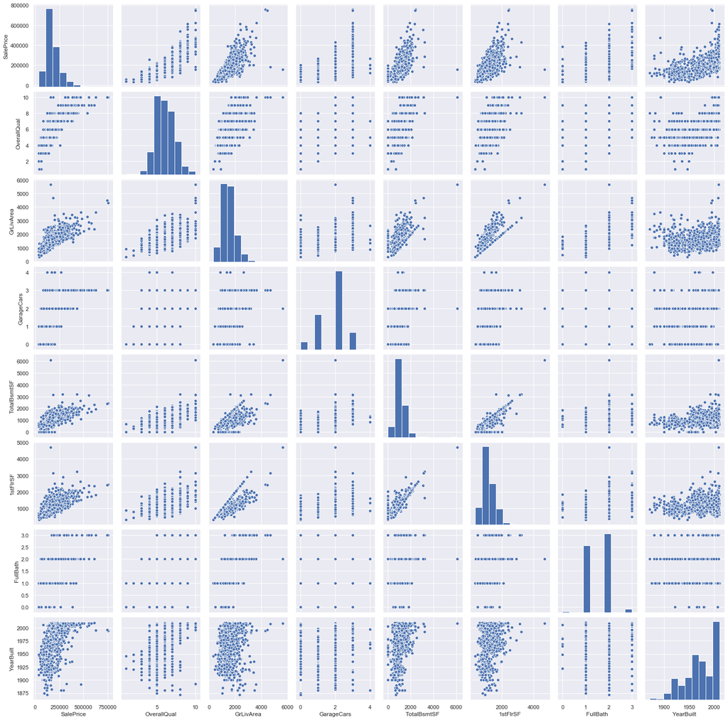

```python
cols = ['SalePrice', 'OverallQual', 'GrLivArea', 'GarageCars', 'TotalBsmtSF', '1stFlrSF', 'FullBath', 'YearBuilt']
sns.pairplot(df[cols], size = 2.5)
plt.show()
```

- Interesting finds:
  - `GrLivArea` and `TotalBsmtSF` - there are line dots, almost like a border. It is not expected to have basements larger than the 1st floor. It could also be an indicator of regulations for approved projects.
  - `1stFlrSF` and `TotalBsmtSF` - also seem to share the same relationship
  - `SalePrice` and `YearBuilt` - the cloud of dots seems to be giving more terrain for price. Seems that as we go forward, house prices are increasing. And faster at that!
  - We see that `OverallQual` and `YearBuilt` have an interesting relationship. Between 1932 and 1962 we don't see houses with `OverallQual` above 8. The Great Depression maybe?

# 5. Further analysis - working smart

## 5.7. Summary

- We can use **correlations** to find **interactions** between variables
- We used a `Heatmap` to visualize **correlations**
- We found new variables of interest:
  - `GarageCars`
  - `FullBath`
- We reforced that `1stFlrSF` might be a variable of interest
- We managed to pick a set of just 7 variables that might help explain our house prices! No need for 81!

# 6. Investigating wanted houses

[figure not shown]

# 6. Investigating wanted houses

## 6.1. Introduction

- These are the variables we chose throughout our **selection** process

```python
cols = ['SalePrice', 'OverallQual', 'GrLivArea', 'GarageCars', 'TotalBsmtSF', '1stFlrSF', 'FullBath', 'YearBuilt']
```

- Dividing our `Numerical` variables - we will need them for the `Scatter Plot`

```python
numerical_cols = ['GrLivArea', 'TotalBsmtSF', '1stFlrSF']
```

- Dividing our `Categorical` variables - we will need them for `Boxplot`

```python
categorical_cols = ['OverallQual', 'GarageCars', 'FullBath', 'YearBuilt']
```

# 6. Investigating wanted houses

## 6.2. Wanted house features - Requirements

(From homework)

We have a pretty rough idea on what our house should have.

For starters, we know that our `HeatingQC` (quality and condition) must be **excellent**, because we live in a cold country. As for the `Heating` system we'd rather use gas, because we are so cold. So we want an `Heating` system that does uses any gas system.

But since we are a modern family we want `CentralAir` air conditioning.

To support our data analytics family we want our `Electrical` system to be flawless, so we definitely have to have "Standard Circuit Breakers".

```python
wanted_features = ['Heating', 'HeatingQC', 'CentralAir', 'Electrical', ]
for f in wanted_features:
    feature_description(f)
```

```
Heating: Type of heating
       Floor	Floor Furnace
       GasA	Gas forced warm air furnace
       GasW	Gas hot water or steam heat
       Grav	Gravity furnace
       OthW	Hot water or steam heat other than gas
       Wall	Wall furnace
HeatingQC: Heating quality and condition
       Ex	Excellent
       Gd	Good
       TA	Average/Typical
       Fa	Fair
       Po	Poor
CentralAir: Central air conditioning
       N	No
       Y	Yes
Electrical: Electrical system
       SBrkr	Standard Circuit Breakers & Romex
       FuseA	Fuse Box over 60 AMP and all Romex wiring (Average)
       FuseF	60 AMP Fuse Box and mostly Romex wiring (Fair)
       FuseP	60 AMP Fuse Box and mostly knob & tube wiring (poor)
       Mix	Mixed
```

- Translating our wishes to **conditions**
- Our objective is to obtain a `pd.DataFrame` with only houses that follow our requirements

```python
hq_cond = df['HeatingQC'] == 'Ex'
gasA_cond = df['Heating'] == 'GasA'
gasW_cond = df['Heating'] == 'GasW'
air_cond = df['CentralAir'] == 'Y'
cb_cond = df['Electrical'] == 'SBrkr'
```

- Getting our `pd.DataFrame` with wanted houses
- **All** requirements will be followed (`and` / `&`)
- We want **either** `GasA` **OR** (`|`) `GasW`

```python
wanted_df = df[hq_cond & (gasA_cond | gasW_cond) & air_cond & cb_cond]
wanted_df[wanted_features].head()
```

|  | Heating | HeatingQC | CentralAir | Electrical |
| --- | --- | --- | --- | --- |
| 0 | GasA | Ex | Y | SBrkr |
| 1 | GasA | Ex | Y | SBrkr |
| 2 | GasA | Ex | Y | SBrkr |
| 4 | GasA | Ex | Y | SBrkr |
| 5 | GasA | Ex | Y | SBrkr |

- And also we want houses that do **NOT** follow our requirements - so we can **compare**
- The special character for this purpose is `~` (tilde)
- This time around we want **all** the houses that are **not** wanted (`True` becomes `False` and `False` becomes `True`)

```python
unwanted_df = df[~(hq_cond & (gasA_cond | gasW_cond) & air_cond & cb_cond)]
unwanted_df[wanted_features].head()
```

|  | Heating | HeatingQC | CentralAir | Electrical |
| --- | --- | --- | --- | --- |
| 3 | GasA | Gd | Y | SBrkr |
| 8 | GasA | Gd | Y | FuseF |
| 12 | GasA | TA | Y | SBrkr |
| 14 | GasA | TA | Y | SBrkr |
| 15 | GasA | Ex | Y | FuseA |

# 6. Investigating wanted houses

## 6.3. Comparing `SalePrice` between wanted and unwanted houses

- We can **compare** the overall picture (**distribution**) using `Histogram` (`sns.displot`)

**`[OBSERVATION]`**: The first plot is always **blue**. In this case **Wanted = Orange**

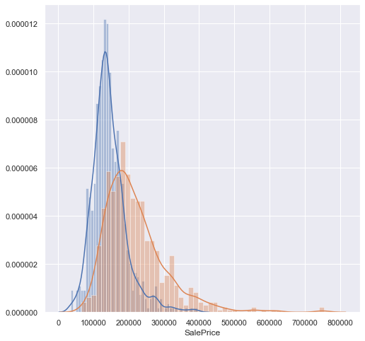

```python
plt.subplots(figsize=(8, 8))
sns.distplot(unwanted_df['SalePrice'], bins=50)
sns.distplot(wanted_df['SalePrice'], bins=50)
```

- Looks like our wanted features make our house a **little bit pricier**
- And it looks like our wishes give rise to a **long tail** in the distribution
  - The few houses that are pricey (> 500000 dollars) are all present

# 6. Investigating wanted houses

## 6.4. Comparing house qualities - `BoxPlot`

- We now want to compare how our **selected** features fare against each other
- For house **qualities** we will use `Categorical` variables - better visualized with a `BoxPlot`
- We will compare them side-by-side

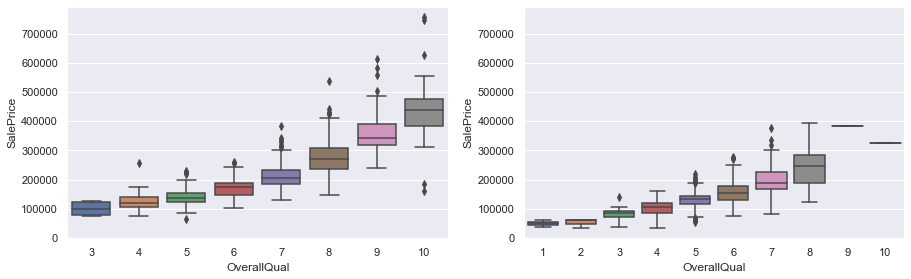

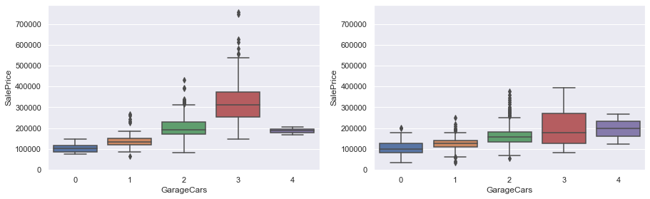

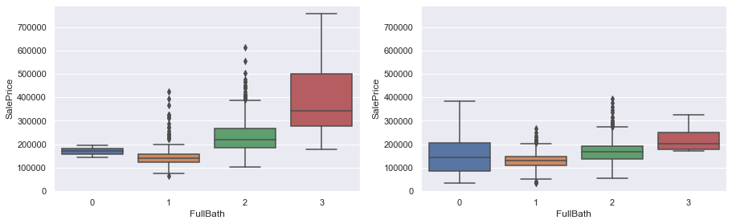

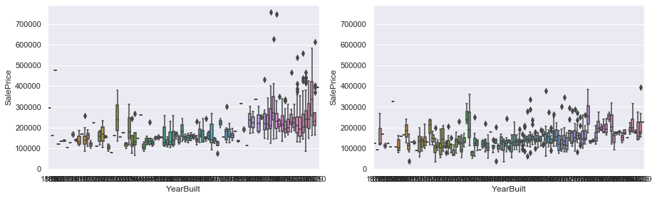

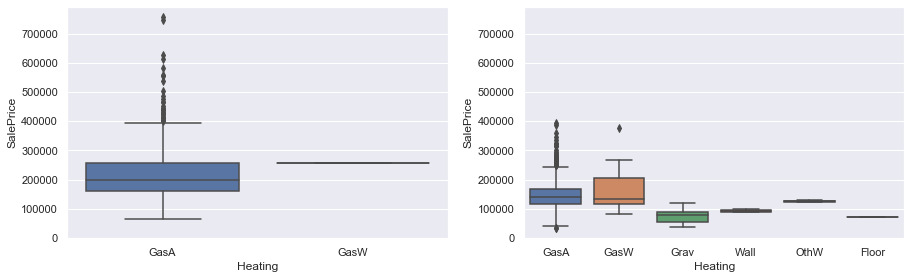

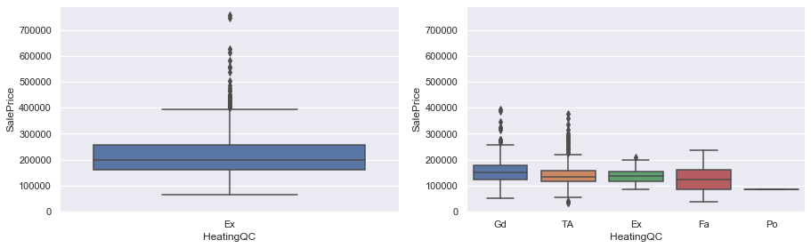

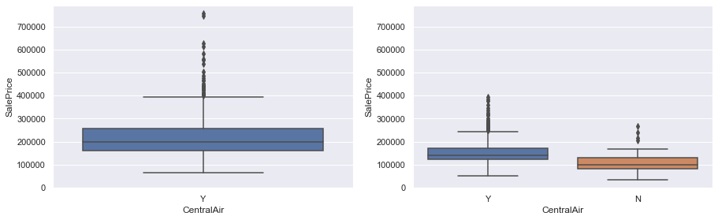

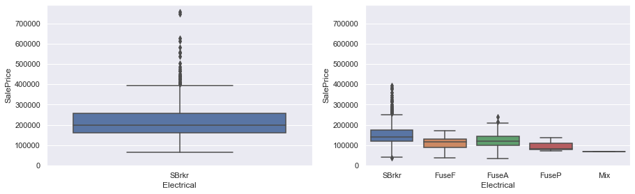

```python
total_variables = len(categorical_cols) + len(wanted_features)
for i, c in enumerate(categorical_cols + wanted_features):
    plt.subplots(figsize=(15, 5*total_variables))

    ax1 = plt.subplot(len(cols), 2, 1)
    f = boxplot(wanted_df, c)

    ax2 = plt.subplot(len(cols), 2, 2, sharey=ax1)
    f = boxplot(unwanted_df, c)

plt.show()
```

**Conclusions**:

- `OverallQual` rises faster in `SalePrice` comparing to unwanted houses
- It is **unlikely** we will have 4 `GarageCars`, with our **conditions** and **requirements**
- `FullBath` (complete bathrooms) **greatly increase** our price - maybe we don't need that many bathrooms
- The `YearBuilt` shows **greater variation** comparing the same years, and an increased price
- `GasW` and `GasA` heating show an **overall increased price** - maybe we should be more enviromentally concerned!
- `HeatingQC` doesn't show much variation...
- In our type of house `CentralAir` is **more expensive** than in houses than we do not want
- Our `Electrical` system seems to be more expensive in both sets of houses. But this one is indispensible because we are an electrical engineer family.

# 6. Investigating wanted houses

## 6.5. Comparing house space - `Scatter`

- We now want to compare how our **space** features fare against each other
- For house **space** we will use `Numerical` variables - better visualized with a `Scatter Plot`
- We will compare them side-by-side

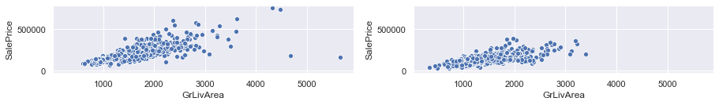

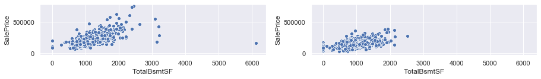

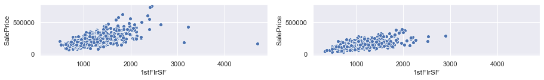

```python
total_variables = len(numerical_cols)
for i, c in enumerate(numerical_cols):
    plt.subplots(figsize=(15, 5*total_variables))

    ax1 = plt.subplot(len(cols), 2, 1)
    f = scatter(wanted_df, c)

    ax2 = plt.subplot(len(cols), 2, 2, sharex=ax1, sharey=ax1)
    f = scatter(unwanted_df, c)

plt.show()
```

**Conclusions**:

- It seems that our preferred houses have a **higher cost** per living space

# 6. Investigating wanted houses

## 6.6. Time to cut our losses

```python
air_cond = df['CentralAir'] == 'N'
cb_cond = df['Electrical'] == 'SBrkr'
bath_cond = df['FullBath'] <= 2
cars_cond = df['GarageCars'] <= 2
```

```python
wanted_df = df[(air_cond & cb_cond & bath_cond & cars_cond)]
print(len(wanted_df))
wanted_df[cols].head()
```

```
49
```

|  | SalePrice | OverallQual | GrLivArea | GarageCars | TotalBsmtSF | 1stFlrSF | FullBath | YearBuilt |
| --- | --- | --- | --- | --- | --- | --- | --- | --- |
| 29 | 68500 | 4 | 520 | 1 | 520 | 520 | 1 | 1927 |
| 30 | 40000 | 4 | 1317 | 1 | 649 | 649 | 1 | 1920 |
| 52 | 110000 | 5 | 816 | 2 | 816 | 816 | 1 | 1963 |
| 61 | 101000 | 5 | 1111 | 1 | 530 | 581 | 1 | 1920 |
| 74 | 107400 | 3 | 1605 | 1 | 840 | 840 | 2 | 1915 |

```python
unwanted_df = df[~(air_cond & cb_cond & bath_cond & cars_cond)]
unwanted_df[cols].head()
```

|  | SalePrice | OverallQual | GrLivArea | GarageCars | TotalBsmtSF | 1stFlrSF | FullBath | YearBuilt |
| --- | --- | --- | --- | --- | --- | --- | --- | --- |
| 0 | 208500 | 7 | 1710 | 2 | 856 | 856 | 2 | 2003 |
| 1 | 181500 | 6 | 1262 | 2 | 1262 | 1262 | 2 | 1976 |
| 2 | 223500 | 7 | 1786 | 2 | 920 | 920 | 2 | 2001 |
| 3 | 140000 | 7 | 1717 | 3 | 756 | 961 | 1 | 1915 |
| 4 | 250000 | 8 | 2198 | 3 | 1145 | 1145 | 2 | 2000 |

```python
len(wanted_df)
```

```
49
```

# 6. Investigating wanted houses

## 6.7. Comparing new house prices

- Repeating the same process as before

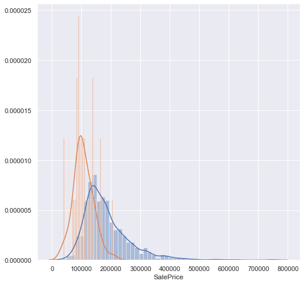

```python
plt.subplots(figsize=(8, 8))
sns.distplot(unwanted_df['SalePrice'], bins=50)
sns.distplot(wanted_df['SalePrice'], bins=50)
```

**Conclusions**:

- Seems that our **wanted** houses became much **cheaper**!

# 6. Investigating wanted houses

## 6.8. Comparing new house qualities

- Repeating the same process as before - `BoxPlot`

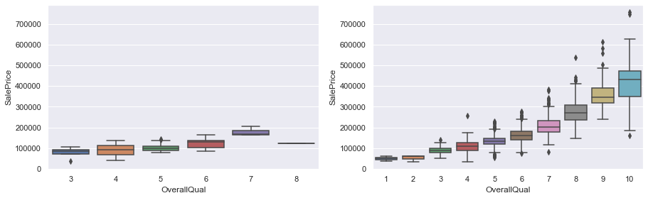

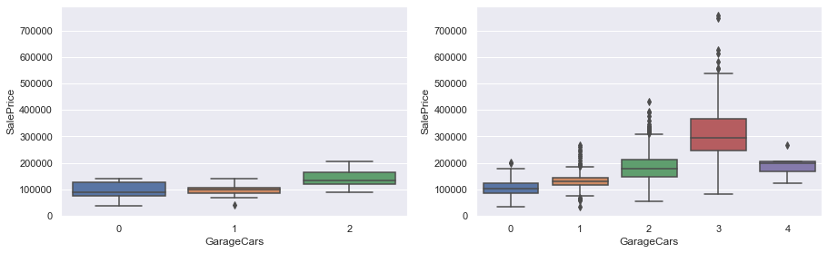

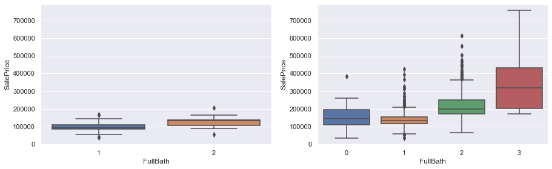

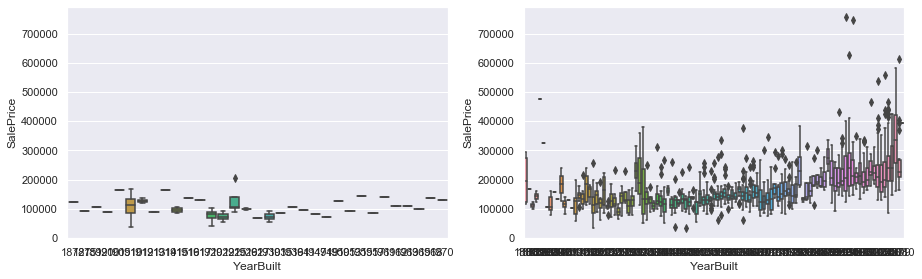

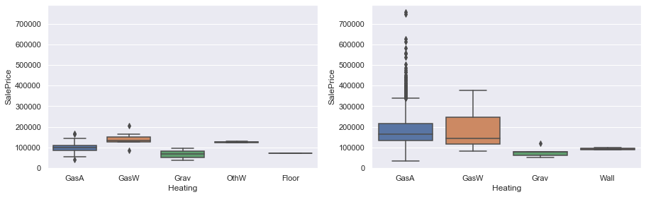

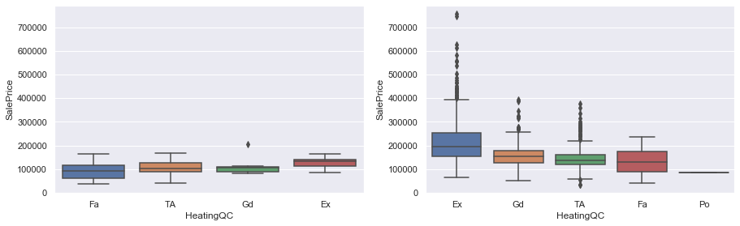

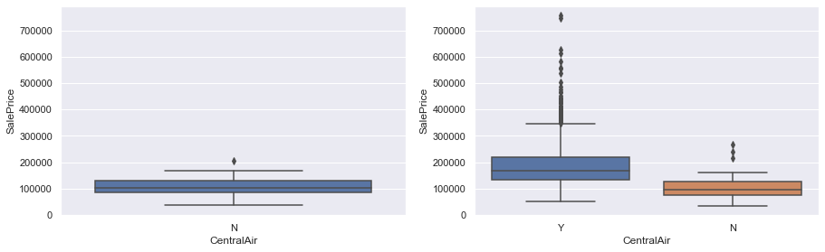

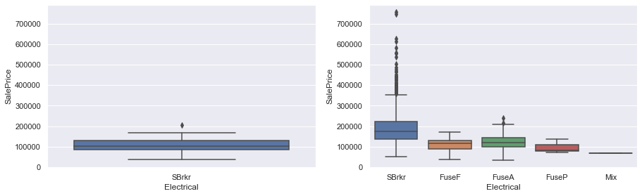

```python
total_variables = len(categorical_cols) + len(wanted_features)
for i, c in enumerate(categorical_cols + wanted_features):
    plt.subplots(figsize=(15, 5*total_variables))

    ax1 = plt.subplot(len(cols), 2, 1)
    f = boxplot(wanted_df, c)

    ax2 = plt.subplot(len(cols), 2, 2, sharey=ax1)
    f = boxplot(unwanted_df, c)

plt.show()
```

**Conclusions**:

- `OverallQual` - wanted houses only go as far as an 8!
- `GarageCars` - within budget. Check!
- `FullBath` - within budget. Check!
- `YearBuilt` - looks like our last wanted house was built in 1970 - 50 years old! Ouch.
- `Heating` and `HeatingQC` - within budget. Check!
- `CentralAir` - maybe not that big of a problem after all.
- `Electrical` - within budget. All systems go!

# 6. Investigating wanted houses

## 6.9. Comparing new house space

- Let's compare how our **wanted** houses relate to the space

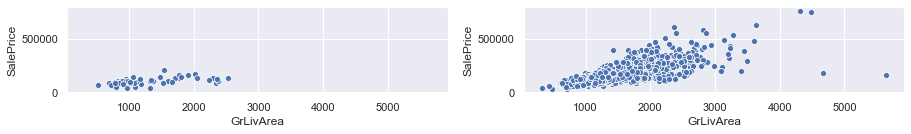

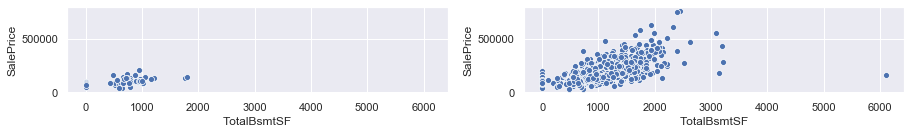

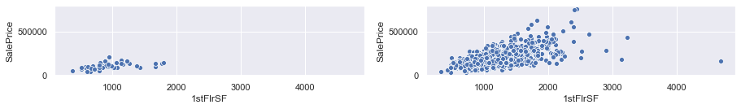

```python
total_variables = len(numerical_cols)
for i, c in enumerate(numerical_cols):
    plt.subplots(figsize=(15, 5*total_variables))

    ax1 = plt.subplot(len(cols), 2, 1)
    f = scatter(wanted_df, c)

    ax2 = plt.subplot(len(cols), 2, 2, sharex=ax1, sharey=ax1)
    f = scatter(unwanted_df, c)

plt.show()
```

**Conclusions**:

- Seems that space is not the greatest culprit of the price
- Doesn't show a linear relationship like before!
- Our requirements are what changes the price of the house

# 6. Investigating wanted houses

## 6.10. Settling on a wanted house

- It is time to schedule our first visit
- This house was chosen with care
- And we have a **numerical** understanding on how the market works - just in case anything funny happens
- We would like to capitalize on houses with an `OverallQual` above 7 - quality at a good price!

```python
wanted_df.loc[wanted_df['OverallQual'] >= 7][cols + wanted_features + ['YearRemodAdd']]
```

|  | SalePrice | OverallQual | GrLivArea | GarageCars | TotalBsmtSF | 1stFlrSF | FullBath | YearBuilt | Heating | HeatingQC | CentralAir | Electrical | YearRemodAdd |
| --- | --- | --- | --- | --- | --- | --- | --- | --- | --- | --- | --- | --- | --- |
| 275 | 205000 | 7 | 1548 | 2 | 952 | 952 | 2 | 1925 | GasW | Gd | N | SBrkr | 2007 |
| 735 | 163000 | 7 | 1768 | 2 | 880 | 880 | 1 | 1914 | GasW | Fa | N | SBrkr | 1970 |
| 974 | 167500 | 7 | 2019 | 2 | 728 | 1136 | 1 | 1910 | GasA | TA | N | SBrkr | 1993 |
| 1349 | 122000 | 8 | 2358 | 0 | 684 | 938 | 2 | 1872 | OthW | Fa | N | SBrkr | 1987 |

- We found a house just a little bit over budget
- `OverallQual` is 7
- Very old house - built in 1925, but **remodelled** in 2007

```python
df.iloc[275].to_frame()
```

|  | 275 |
| --- | --- |
| Id | 276 |
| MSSubClass | 50 |
| MSZoning | RL |
| LotFrontage | 55 |
| LotArea | 7264 |
| Street | Pave |
| Alley | NaN |
| LotShape | Reg |
| LandContour | Lvl |
| Utilities | AllPub |
| LotConfig | Inside |
| LandSlope | Gtl |
| Neighborhood | BrkSide |
| Condition1 | Norm |
| Condition2 | Norm |
| BldgType | 1Fam |
| HouseStyle | 1.5Fin |
| OverallQual | 7 |
| OverallCond | 7 |
| YearBuilt | 1925 |
| YearRemodAdd | 2007 |
| RoofStyle | Gable |
| RoofMatl | CompShg |
| Exterior1st | Wd Sdng |
| Exterior2nd | Wd Sdng |
| MasVnrType | None |
| MasVnrArea | 0 |
| ExterQual | Gd |
| ExterCond | Gd |
| Foundation | BrkTil |

[output cut: 51 more lines]